# Exploratory Data Analysis

Lucas Avelar

2023-03-10

```r
#load libraries
library(DigitalMethodsData)
library(tidyverse)
```

```r
library(ggplot2)
#load data
data("gayguides")
```

#Step 1 - Formulate the question > What types of location were documented in the U.S. Territories, i.e., Puerto Rico, Guam, and Virgin Islands between 1965 and 1980? Calculate if each type increased or decreased in numbers over time. Lastly, demonstrate the percentage of locations that were assigned an amenity feature of “AYOR”, “HOT” or included “inquire locally” in the description or address fields.

#Steps 2 and 3 - Read the data and Check the packaging

```r
#load libraries
library(DigitalMethodsData)
library(tidyverse)
library(ggplot2)
#load data and read it
data("gayguides")

#Check the packaging
nrow(gayguides)
```

```
## [1] 60698
```

```r
ncol(gayguides)
```

```
## [1] 14
```

#Step 4 - Run str()

```r
str(gayguides)
```

```
## 'data.frame':    60698 obs. of  14 variables:
##  $ X              : int  1 2 3 4 5 6 7 8 9 10 ...
##  $ ID             : chr  "3213" "2265" "3269" "3388" ...
##  $ title          : chr  "'B.A.'" "'B.A.' Beach" "'B.A.' Beach" "'B.A.' Beach" ...
##  $ description    : chr  "(woods & ponds)" "2 mi. E." "nr. Salt Air Beach" "nr. Evergreen Floating Bridge" ...
##  $ streetaddress  : chr  "" "Rte. 2" "" "" ...
##  $ type           : chr  "Cruising Areas" "Cruising Areas" "Cruising Areas" "Cruising Areas" ...
##  $ amenityfeatures: chr  "Cruisy Area" "Cruisy Area" "Cruisy Area" "Cruisy Area" ...
##  $ city           : chr  "Lake Placid" "Troy" "Salt Lake City" "Seattle" ...
##  $ state          : chr  "NY" "NY" "UT" "WA" ...
##  $ Year           : int  1982 1981 1981 1981 1982 1983 1983 1983 1983 1984 ...
##  $ notes          : chr  "" "" "" "" ...
##  $ lat            : num  44.3 42.7 40.7 47.6 42.7 ...
##  $ lon            : num  -74 -73.7 -112.2 -122.3 -73.7 ...
##  $ status         : chr  "Location could not be verified. General city or location coordinates used." "Location could not be verified. General city or location coordinates used." "Location could not be verified. General city or location coordinates used." "Location could not be verified. General …
```

#Step 5 - Look at the top and the bottom of the data

```r
head(gayguides[, c(6:9)])
```

```
##             type amenityfeatures           city state
## 1 Cruising Areas     Cruisy Area    Lake Placid    NY
## 2 Cruising Areas     Cruisy Area           Troy    NY
## 3 Cruising Areas     Cruisy Area Salt Lake City    UT
## 4 Cruising Areas     Cruisy Area        Seattle    WA
## 5 Cruising Areas     Cruisy Area           Troy    NY
## 6 Cruising Areas     Cruisy Area        Seattle    WA
```

```r
tail(gayguides[, c(6:9)])
```

```
##             type
## 60693 Bars/Clubs
## 60694 Bars/Clubs
## 60695 Bars/Clubs
## 60696 Bars/Clubs
## 60697 Bars/Clubs
## 60698 Bars/Clubs
##                                                                                   amenityfeatures
## 60693                                                                                     (G),(*)
## 60694                                                                                         (G)
## 60695                                                                                         (L)
## 60696                                                         (M) - Mixed Crowds - Some Straights
## 60697 (M) - Mixed Crowds - Some Straights,(YC) - Young and/or collegiate types,(*) - Very popular
## 60698 (M) - Mixed Crowds - Some Straights,(YC) - Young and/or collegiate types,(*) - Very popular
##           city state
## 60693 Hato Ray    PR
## 60694 Hato Ray    PR
## 60695 Hato Ray    PR
## 60696    Agana    GU
## 60697    Agana    GU
## 60698    Agana    GU
```

#Step 6 - Check your “n”s

```r
table(gayguides$Year)
```

```
##
## 1965 1966 1968 1969 1970 1971 1972 1973 1974 1975 1976 1977 1978 1979 1980 1981
##  785  867  977 1199 1303 1401 1787 2214 2580 2861 2983 3493 3740 4057 4468 4690
## 1982 1983 1984 1985
## 4873 5298 5376 5746
```

# this is helpful to check data integrity after reading it. As Peng suggests in his book, if you know the dataset should have records for all years between 1965 and 1985, this helps to make sure it really does and that the number of records per year does not seem off. For the purpose of this exercise, I find it reasonable to skip Step 7 “Validade with at least one external data source”.

#Step 8 - Try the easy solution first (provide prima facie evidence for the original question)

```r
#let's subset gayguides to get to what truly matters for the question
gg.territories <- gayguides %>%
  filter(state == 'GU' | state == 'PR' | state == 'VI')
head(gg.territories)
```

```
##       X   ID              title
## 1  1095 1959              4-Oct
## 2  5568 1780       Chicken Lips
## 3 11576 1782 Hilton Hotel Beach
## 4 11577 1960 Hilton Hotel Beach
## 5 12370 1779              J & V
## 6 13161 1955      Korner Lounge
##                                                             description
## 1                                   (Some M, B, YC) (Disco) Guam Hilton
## 2                                    (Disco) (Some B) (Basement) (AYOR)
## 3
## 4
## 5                                                            (Best bet)
## 6 (Some M, L, Military) (Upstairs) (Call John for directions - 477-7042
##                       streetaddress                 type
```

[output cut: 20 more lines]

```r
tail(gg.territories)
```

```
##         X    ID           title               description streetaddress
## 542 60693 PR351       Boccachio            (Natives only)
## 543 60694 PR366       Boccachio            (Natives only)
## 544 60695 PR377       Boccachio            (Natives only)
## 545 60696 GU002   Mi Elena Club (Inquire locally) (Agana)          <NA>
## 546 60697 GU015 Star Cafe & Bar Downtown, opp. Agana Loop          <NA>
## 547 60698 GU019 Star Cafe & Bar Downtown, opp. Agana Loop          <NA>
##           type
## 542 Bars/Clubs
## 543 Bars/Clubs
## 544 Bars/Clubs
## 545 Bars/Clubs
## 546 Bars/Clubs
## 547 Bars/Clubs
##                                                                                 amenityfeatures
```

[output cut: 20 more lines]

```r
#let's group by type, state, and Year and get the count for every combination
gg.terr.type.year <- gg.territories %>%
  separate_rows(type, sep=",")%>%
  group_by(type, state, Year) %>%
  summarise(count = n())
```

#cool. but what now?

```r
#let's first mutate "gg.terr.type.year" to change the spelling of the mismatching values.
gg.terr.type.year <- gg.terr.type.year %>%
  mutate(type = fct_collapse(type,
                             "Hotels" = c("Hotel", "Hotels"),
                             "Cruisy Areas" = c("Cruising Areas", "Cruisy Areas")
  )
  )
```

#now I assume I can try to collapse observations with the same values by grouping by type again and summarising the count.

```r
gg.terr.type.count <- gg.terr.type.year %>%
  group_by(type) %>%
  summarise(count = sum(count))
```

#We can surely answer the first part of the question: > What types of location were documented in the U.S. Territories, i.e., Puerto Rico, Guam, and Virgin Islands between 1965 and 1980? R: Bars/Clubs, Baths, Cruisy Areas, Hotels, and Restaurants.

#now how to answer the second part? > Calculate if each type increased or decreased in numbers over time.

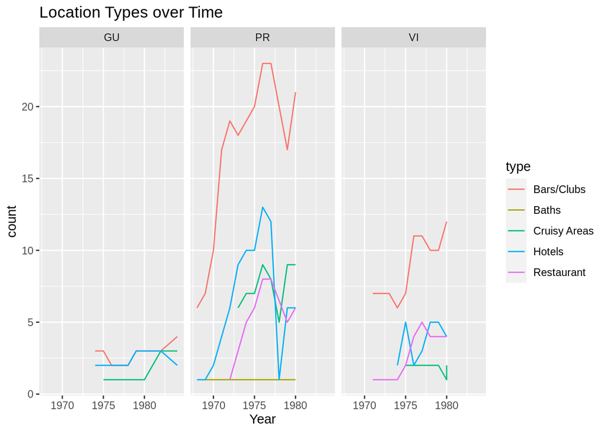

```r
#use ggplot to create a plot that demonstrates the growth or decrease of each location type over time.
#make a plot for each of the territories.
#line chart, with years as x axis, count as y axis, and types for colors.
#state as facet.
ggplot(data = gg.terr.type.year, mapping = aes(x = Year, y = count, color = type)) +
  geom_line() + labs(x = "Year", y = "count", title = "Location Types over Time") + facet_wrap(~state)
```

#now to answer the last part of the question: >Lastly, demonstrate the percentage of locations that were assigned an amenity feature of “AYOR”, “HOT” or included “inquire locally” in the description or address fields.

```r
gg.terr.risk <- gg.territories %>%
  filter(grepl('AYOR', amenityfeatures) | grepl('HOT', amenityfeatures) | grepl('locally', description)) #%>%
 ##group_by(type, amenityfeatures) %>%
 ## mutate(percent_rank())
```

#ok, I could literally just calculate how many % of 547 is 16 entries. But I want to visualize that in a plot. I wanted to use mutate() and percent_rank().